# Risk Factor Analysis

## Outcome Variable

**Outcome Variable:** ever_co

## Predictor Variables

**Intervention Variable:** predfeed3

**Adjustment Set:**

- arm
- sex
- month
- brthmon
- W_mage
- meducyrs
- feducyrs
- hhwealth_quart
- hfoodsec
- W_mhtcm
- W_mwtkg
- W_mbmi
- vagbrth
- W_gagebrth
- W_birthwt
- W_birthlen
- W_nrooms
- W_nchldlt5
- W_parity
- impfloor
- impsan
- safeh20
- delta_W_mage
- delta_meducyrs
- delta_feducyrs
- delta_hhwealth_quart
- delta_hfoodsec
- delta_W_mhtcm
- delta_W_mwtkg
- delta_W_mbmi
- delta_vagbrth
- delta_W_gagebrth
- delta_W_birthwt
- delta_W_birthlen
- delta_W_nrooms
- delta_W_nchldlt5
- delta_W_parity
- delta_impfloor
- delta_impsan
- delta_safeh20

## Stratifying Variables

The analysis was stratified on these variable(s):

- agecat
- studyid
- country

## Data Summary

| agecat | studyid | country | predfeed3 | ever_co | n_cell | n |
| --- | --- | --- | --- | --- | --- | --- |
| 0-24 months | EE | PAKISTAN | 1 | 0 | 17 | 39 |
| 0-24 months | EE | PAKISTAN | 1 | 1 | 22 | 39 |
| 0-24 months | EE | PAKISTAN | 0 | 0 | 0 | 39 |
| 0-24 months | EE | PAKISTAN | 0 | 1 | 0 | 39 |
| 0-24 months | GMS-Nepal | NEPAL | 1 | 0 | 247 | 458 |
| 0-24 months | GMS-Nepal | NEPAL | 1 | 1 | 133 | 458 |
| 0-24 months | GMS-Nepal | NEPAL | 0 | 0 | 54 | 458 |
| 0-24 months | GMS-Nepal | NEPAL | 0 | 1 | 24 | 458 |
| 0-24 months | JiVitA-3 | BANGLADESH | 1 | 0 | 12292 | 14981 |
| 0-24 months | JiVitA-3 | BANGLADESH | 1 | 1 | 1269 | 14981 |
| 0-24 months | JiVitA-3 | BANGLADESH | 0 | 0 | 1289 | 14981 |
| 0-24 months | JiVitA-3 | BANGLADESH | 0 | 1 | 131 | 14981 |
| 0-24 months | JiVitA-4 | BANGLADESH | 1 | 0 | 132 | 165 |
| 0-24 months | JiVitA-4 | BANGLADESH | 1 | 1 | 16 | 165 |
| 0-24 months | JiVitA-4 | BANGLADESH | 0 | 0 | 13 | 165 |
| 0-24 months | JiVitA-4 | BANGLADESH | 0 | 1 | 4 | 165 |
| 0-24 months | MAL-ED | BANGLADESH | 1 | 0 | 167 | 244 |
| 0-24 months | MAL-ED | BANGLADESH | 1 | 1 | 33 | 244 |
| 0-24 months | MAL-ED | BANGLADESH | 0 | 0 | 39 | 244 |
| 0-24 months | MAL-ED | BANGLADESH | 0 | 1 | 5 | 244 |
| 0-24 months | MAL-ED | BRAZIL | 1 | 0 | 95 | 202 |
| 0-24 months | MAL-ED | BRAZIL | 1 | 1 | 3 | 202 |
| 0-24 months | MAL-ED | BRAZIL | 0 | 0 | 104 | 202 |
| 0-24 months | MAL-ED | BRAZIL | 0 | 1 | 0 | 202 |
| 0-24 months | MAL-ED | INDIA | 1 | 0 | 117 | 216 |
| 0-24 months | MAL-ED | INDIA | 1 | 1 | 34 | 216 |
| 0-24 months | MAL-ED | INDIA | 0 | 0 | 50 | 216 |
| 0-24 months | MAL-ED | INDIA | 0 | 1 | 15 | 216 |
| 0-24 months | MAL-ED | NEPAL | 1 | 0 | 100 | 228 |
| 0-24 months | MAL-ED | NEPAL | 1 | 1 | 14 | 228 |

[output cut: 102 more lines]

The following strata were considered:

- agecat: 0-24 months, studyid: EE, country: PAKISTAN
- agecat: 0-24 months, studyid: GMS-Nepal, country: NEPAL
- agecat: 0-24 months, studyid: JiVitA-3, country: BANGLADESH
- agecat: 0-24 months, studyid: JiVitA-4, country: BANGLADESH
- agecat: 0-24 months, studyid: MAL-ED, country: BANGLADESH
- agecat: 0-24 months, studyid: MAL-ED, country: BRAZIL
- agecat: 0-24 months, studyid: MAL-ED, country: INDIA
- agecat: 0-24 months, studyid: MAL-ED, country: NEPAL
- agecat: 0-24 months, studyid: MAL-ED, country: PERU
- agecat: 0-24 months, studyid: MAL-ED, country: SOUTH AFRICA
- agecat: 0-24 months, studyid: MAL-ED, country: TANZANIA, UNITED REPUBLIC OF
- agecat: 0-6 months, studyid: EE, country: PAKISTAN
- agecat: 0-6 months, studyid: GMS-Nepal, country: NEPAL
- agecat: 0-6 months, studyid: JiVitA-3, country: BANGLADESH
- agecat: 0-6 months, studyid: JiVitA-4, country: BANGLADESH
- agecat: 0-6 months, studyid: MAL-ED, country: BANGLADESH
- agecat: 0-6 months, studyid: MAL-ED, country: BRAZIL
- agecat: 0-6 months, studyid: MAL-ED, country: INDIA
- agecat: 0-6 months, studyid: MAL-ED, country: NEPAL
- agecat: 0-6 months, studyid: MAL-ED, country: PERU
- agecat: 0-6 months, studyid: MAL-ED, country: SOUTH AFRICA
- agecat: 0-6 months, studyid: MAL-ED, country: TANZANIA, UNITED REPUBLIC OF
- agecat: 6-24 months, studyid: EE, country: PAKISTAN
- agecat: 6-24 months, studyid: GMS-Nepal, country: NEPAL
- agecat: 6-24 months, studyid: JiVitA-3, country: BANGLADESH
- agecat: 6-24 months, studyid: JiVitA-4, country: BANGLADESH
- agecat: 6-24 months, studyid: MAL-ED, country: BANGLADESH
- agecat: 6-24 months, studyid: MAL-ED, country: BRAZIL
- agecat: 6-24 months, studyid: MAL-ED, country: INDIA
- agecat: 6-24 months, studyid: MAL-ED, country: NEPAL
- agecat: 6-24 months, studyid: MAL-ED, country: PERU
- agecat: 6-24 months, studyid: MAL-ED, country: SOUTH AFRICA
- agecat: 6-24 months, studyid: MAL-ED, country: TANZANIA, UNITED REPUBLIC OF

### Dropped Strata

Some strata were dropped due to rare outcomes:

- agecat: 0-24 months, studyid: EE, country: PAKISTAN
- agecat: 0-24 months, studyid: JiVitA-4, country: BANGLADESH
- agecat: 0-24 months, studyid: MAL-ED, country: BRAZIL
- agecat: 0-24 months, studyid: MAL-ED, country: PERU
- agecat: 0-24 months, studyid: MAL-ED, country: SOUTH AFRICA
- agecat: 0-24 months, studyid: MAL-ED, country: TANZANIA, UNITED REPUBLIC OF
- agecat: 0-6 months, studyid: EE, country: PAKISTAN
- agecat: 0-6 months, studyid: JiVitA-4, country: BANGLADESH
- agecat: 0-6 months, studyid: MAL-ED, country: BANGLADESH
- agecat: 0-6 months, studyid: MAL-ED, country: BRAZIL
- agecat: 0-6 months, studyid: MAL-ED, country: NEPAL
- agecat: 0-6 months, studyid: MAL-ED, country: PERU
- agecat: 0-6 months, studyid: MAL-ED, country: SOUTH AFRICA
- agecat: 0-6 months, studyid: MAL-ED, country: TANZANIA, UNITED REPUBLIC OF
- agecat: 6-24 months, studyid: EE, country: PAKISTAN
- agecat: 6-24 months, studyid: JiVitA-4, country: BANGLADESH
- agecat: 6-24 months, studyid: MAL-ED, country: BANGLADESH
- agecat: 6-24 months, studyid: MAL-ED, country: BRAZIL
- agecat: 6-24 months, studyid: MAL-ED, country: NEPAL
- agecat: 6-24 months, studyid: MAL-ED, country: PERU
- agecat: 6-24 months, studyid: MAL-ED, country: SOUTH AFRICA
- agecat: 6-24 months, studyid: MAL-ED, country: TANZANIA, UNITED REPUBLIC OF

## Methods Detail

We’re interested in the causal parameters $E[Y_a]$ for all values of $a \in \mathcal{A}$. These parameters represent the mean outcome if, possibly contrary to fact, we intervened to set all units to have $A=a$. Under the randomization and positivity assumptions, these are identified by the statistical parameters $\psi_a=E_W[E_{Y|A,W}(Y|A=a,W)]$. In addition, we’re interested in the mean of $Y$, $E[Y]$ under no intervention (the observed mean). We will estimate these parameters by using SuperLearner to fit the relevant likelihood factors – $E_{Y|A,W}(Y|A=a,W)$ and $p(A=a|W)$, and then updating our likelihood fit using a joint TMLE.

For unadjusted analyses ($W=\{\}$), initial likelihoods were estimated using Lrnr_glm to estimate the simple $E(Y|A)$ and Lrnr_mean to estimate $p(A)$. For adjusted analyses, a small library containing Lrnr_glmnet, Lrnr_xgboost, and Lrnr_mean was used.

Having estimated these parameters, we will then use the delta method to estimate relative risks and attributable risks relative to a prespecified baseline level of $A$.

# Results Detail

## Results Plots

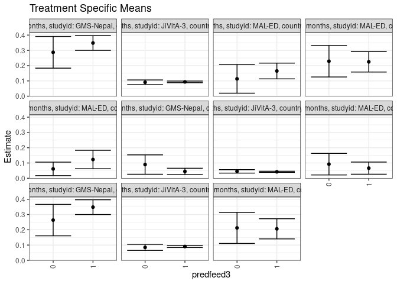

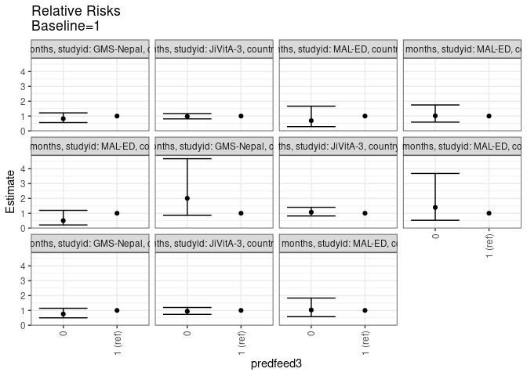

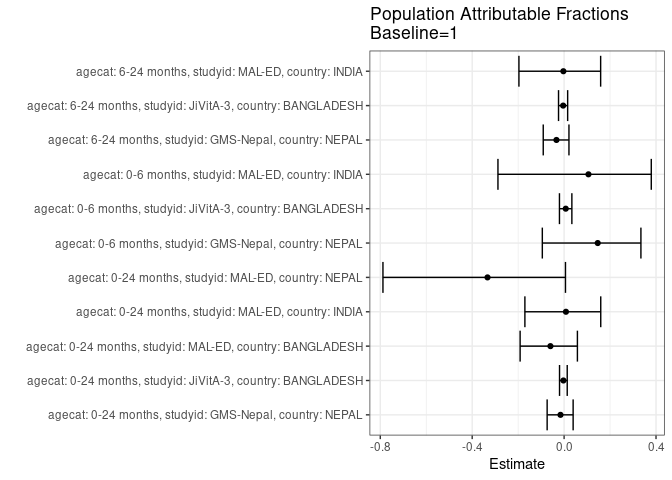

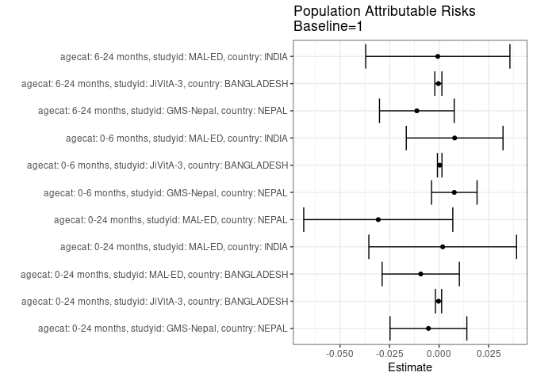

## Results Table

### Parameter: TSM

| agecat | studyid | country | intervention_level | baseline_level | estimate | ci_lower | ci_upper |
| --- | --- | --- | --- | --- | --- | --- | --- |
| 0-24 months | GMS-Nepal | NEPAL | 1 | NA | 0.3481764 | 0.3001383 | 0.3962145 |
| 0-24 months | GMS-Nepal | NEPAL | 0 | NA | 0.2872258 | 0.1835406 | 0.3909110 |
| 0-24 months | JiVitA-3 | BANGLADESH | 1 | NA | 0.0937342 | 0.0883968 | 0.0990715 |
| 0-24 months | JiVitA-3 | BANGLADESH | 0 | NA | 0.0910150 | 0.0755402 | 0.1064898 |
| 0-24 months | MAL-ED | BANGLADESH | 1 | NA | 0.1650000 | 0.1134522 | 0.2165478 |
| 0-24 months | MAL-ED | BANGLADESH | 0 | NA | 0.1136364 | 0.0196688 | 0.2076040 |
| 0-24 months | MAL-ED | INDIA | 1 | NA | 0.2250311 | 0.1580875 | 0.2919746 |
| 0-24 months | MAL-ED | INDIA | 0 | NA | 0.2287911 | 0.1257532 | 0.3318291 |
| 0-24 months | MAL-ED | NEPAL | 1 | NA | 0.1228070 | 0.0624248 | 0.1831893 |
| 0-24 months | MAL-ED | NEPAL | 0 | NA | 0.0614035 | 0.0172377 | 0.1055693 |
| 0-6 months | GMS-Nepal | NEPAL | 1 | NA | 0.0447368 | 0.0239291 | 0.0655446 |
| 0-6 months | GMS-Nepal | NEPAL | 0 | NA | 0.0897436 | 0.0262457 | 0.1532414 |
| 0-6 months | JiVitA-3 | BANGLADESH | 1 | NA | 0.0422268 | 0.0385059 | 0.0459477 |
| 0-6 months | JiVitA-3 | BANGLADESH | 0 | NA | 0.0451362 | 0.0338112 | 0.0564611 |
| 0-6 months | MAL-ED | INDIA | 1 | NA | 0.0662252 | 0.0264694 | 0.1059809 |
| 0-6 months | MAL-ED | INDIA | 0 | NA | 0.0923077 | 0.0217755 | 0.1628399 |
| 6-24 months | GMS-Nepal | NEPAL | 1 | NA | 0.3482640 | 0.2999355 | 0.3965925 |
| 6-24 months | GMS-Nepal | NEPAL | 0 | NA | 0.2634190 | 0.1604980 | 0.3663401 |
| 6-24 months | JiVitA-3 | BANGLADESH | 1 | NA | 0.0905132 | 0.0840224 | 0.0970041 |
| 6-24 months | JiVitA-3 | BANGLADESH | 0 | NA | 0.0849140 | 0.0649495 | 0.1048785 |
| 6-24 months | MAL-ED | INDIA | 1 | NA | 0.2063941 | 0.1403840 | 0.2724041 |
| 6-24 months | MAL-ED | INDIA | 0 | NA | 0.2123413 | 0.1105820 | 0.3141006 |

### Parameter: E(Y)

| agecat | studyid | country | intervention_level | baseline_level | estimate | ci_lower | ci_upper |
| --- | --- | --- | --- | --- | --- | --- | --- |
| 0-24 months | GMS-Nepal | NEPAL | NA | NA | 0.3427948 | 0.2992779 | 0.3863116 |
| 0-24 months | JiVitA-3 | BANGLADESH | NA | NA | 0.0934517 | 0.0884729 | 0.0984306 |
| 0-24 months | MAL-ED | BANGLADESH | NA | NA | 0.1557377 | 0.1101466 | 0.2013289 |
| 0-24 months | MAL-ED | INDIA | NA | NA | 0.2268519 | 0.1708720 | 0.2828317 |
| 0-24 months | MAL-ED | NEPAL | NA | NA | 0.0921053 | 0.0544873 | 0.1297232 |
| 0-6 months | GMS-Nepal | NEPAL | NA | NA | 0.0524017 | 0.0319714 | 0.0728321 |
| 0-6 months | JiVitA-3 | BANGLADESH | NA | NA | 0.0425304 | 0.0390546 | 0.0460063 |
| 0-6 months | MAL-ED | INDIA | NA | NA | 0.0740741 | 0.0390675 | 0.1090807 |
| 6-24 months | GMS-Nepal | NEPAL | NA | NA | 0.3370288 | 0.2933549 | 0.3807028 |
| 6-24 months | JiVitA-3 | BANGLADESH | NA | NA | 0.0901332 | 0.0839189 | 0.0963475 |
| 6-24 months | MAL-ED | INDIA | NA | NA | 0.2057416 | 0.1508055 | 0.2606778 |

### Parameter: RR

| agecat | studyid | country | intervention_level | baseline_level | estimate | ci_lower | ci_upper |
| --- | --- | --- | --- | --- | --- | --- | --- |
| 0-24 months | GMS-Nepal | NEPAL | 1 | 1 | 1.0000000 | 1.0000000 | 1.000000 |
| 0-24 months | GMS-Nepal | NEPAL | 0 | 1 | 0.8249433 | 0.5603876 | 1.214394 |
| 0-24 months | JiVitA-3 | BANGLADESH | 1 | 1 | 1.0000000 | 1.0000000 | 1.000000 |
| 0-24 months | JiVitA-3 | BANGLADESH | 0 | 1 | 0.9709906 | 0.8093709 | 1.164883 |
| 0-24 months | MAL-ED | BANGLADESH | 1 | 1 | 1.0000000 | 1.0000000 | 1.000000 |
| 0-24 months | MAL-ED | BANGLADESH | 0 | 1 | 0.6887052 | 0.2845336 | 1.666991 |
| 0-24 months | MAL-ED | INDIA | 1 | 1 | 1.0000000 | 1.0000000 | 1.000000 |
| 0-24 months | MAL-ED | INDIA | 0 | 1 | 1.0167091 | 0.5911829 | 1.748524 |
| 0-24 months | MAL-ED | NEPAL | 1 | 1 | 1.0000000 | 1.0000000 | 1.000000 |
| 0-24 months | MAL-ED | NEPAL | 0 | 1 | 0.5000000 | 0.2092107 | 1.194968 |
| 0-6 months | GMS-Nepal | NEPAL | 1 | 1 | 1.0000000 | 1.0000000 | 1.000000 |
| 0-6 months | GMS-Nepal | NEPAL | 0 | 1 | 2.0060332 | 0.8602153 | 4.678096 |
| 0-6 months | JiVitA-3 | BANGLADESH | 1 | 1 | 1.0000000 | 1.0000000 | 1.000000 |
| 0-6 months | JiVitA-3 | BANGLADESH | 0 | 1 | 1.0688988 | 0.8154253 | 1.401164 |
| 0-6 months | MAL-ED | INDIA | 1 | 1 | 1.0000000 | 1.0000000 | 1.000000 |
| 0-6 months | MAL-ED | INDIA | 0 | 1 | 1.3938462 | 0.5274805 | 3.683183 |
| 6-24 months | GMS-Nepal | NEPAL | 1 | 1 | 1.0000000 | 1.0000000 | 1.000000 |
| 6-24 months | GMS-Nepal | NEPAL | 0 | 1 | 0.7563774 | 0.4999767 | 1.144267 |
| 6-24 months | JiVitA-3 | BANGLADESH | 1 | 1 | 1.0000000 | 1.0000000 | 1.000000 |
| 6-24 months | JiVitA-3 | BANGLADESH | 0 | 1 | 0.9381394 | 0.7348392 | 1.197685 |
| 6-24 months | MAL-ED | INDIA | 1 | 1 | 1.0000000 | 1.0000000 | 1.000000 |
| 6-24 months | MAL-ED | INDIA | 0 | 1 | 1.0288149 | 0.5775923 | 1.832539 |

### Parameter: PAR

| agecat | studyid | country | intervention_level | baseline_level | estimate | ci_lower | ci_upper |
| --- | --- | --- | --- | --- | --- | --- | --- |
| 0-24 months | GMS-Nepal | NEPAL | 1 | NA | -0.0053816 | -0.0247651 | 0.0140018 |
| 0-24 months | JiVitA-3 | BANGLADESH | 1 | NA | -0.0002824 | -0.0018472 | 0.0012823 |
| 0-24 months | MAL-ED | BANGLADESH | 1 | NA | -0.0092623 | -0.0287483 | 0.0102237 |
| 0-24 months | MAL-ED | INDIA | 1 | NA | 0.0018208 | -0.0354545 | 0.0390960 |
| 0-24 months | MAL-ED | NEPAL | 1 | NA | -0.0307018 | -0.0683197 | 0.0069162 |
| 0-6 months | GMS-Nepal | NEPAL | 1 | NA | 0.0076649 | -0.0038202 | 0.0191500 |
| 0-6 months | JiVitA-3 | BANGLADESH | 1 | NA | 0.0003036 | -0.0008428 | 0.0014500 |
| 0-6 months | MAL-ED | INDIA | 1 | NA | 0.0078489 | -0.0165679 | 0.0322658 |
| 6-24 months | GMS-Nepal | NEPAL | 1 | NA | -0.0112352 | -0.0300915 | 0.0076212 |
| 6-24 months | JiVitA-3 | BANGLADESH | 1 | NA | -0.0003800 | -0.0021690 | 0.0014090 |
| 6-24 months | MAL-ED | INDIA | 1 | NA | -0.0006524 | -0.0370495 | 0.0357446 |

### Parameter: PAF

| agecat | studyid | country | intervention_level | baseline_level | estimate | ci_lower | ci_upper |
| --- | --- | --- | --- | --- | --- | --- | --- |
| 0-24 months | GMS-Nepal | NEPAL | 1 | NA | -0.0156993 | -0.0738376 | 0.0392914 |
| 0-24 months | JiVitA-3 | BANGLADESH | 1 | NA | -0.0030224 | -0.0198948 | 0.0135709 |
| 0-24 months | MAL-ED | BANGLADESH | 1 | NA | -0.0594737 | -0.1914494 | 0.0578832 |
| 0-24 months | MAL-ED | INDIA | 1 | NA | 0.0080263 | -0.1706724 | 0.1594474 |
| 0-24 months | MAL-ED | NEPAL | 1 | NA | -0.3333333 | -0.7884039 | 0.0059417 |
| 0-6 months | GMS-Nepal | NEPAL | 1 | NA | 0.1462719 | -0.0948184 | 0.3342717 |
| 0-6 months | JiVitA-3 | BANGLADESH | 1 | NA | 0.0071390 | -0.0202258 | 0.0337698 |
| 0-6 months | MAL-ED | INDIA | 1 | NA | 0.1059603 | -0.2879157 | 0.3793794 |
| 6-24 months | GMS-Nepal | NEPAL | 1 | NA | -0.0333360 | -0.0908020 | 0.0211026 |
| 6-24 months | JiVitA-3 | BANGLADESH | 1 | NA | -0.0042160 | -0.0242597 | 0.0154354 |
| 6-24 months | MAL-ED | INDIA | 1 | NA | -0.0031712 | -0.1966336 | 0.1590137 |